# Rozlišovacie testy a Thurstonov model

Blok 3 · cvičenia 13 – 14

Senzometria v R · SaIT

## Problém: 42 % nie je vždy 42 %

- Triangel: 42 zo 100 správnych odpovedí
- 2-AFC: 76 zo 100 správnych odpovedí

Ktorý produkt sa od kontroly líši viac?

**Rovnako.** Oba výsledky zodpovedajú rovnakému rozdielu medzi vzorkami. Podiel správnych odpovedí závisí od **metódy**, nie len od vzoriek.

## Thurstonov model

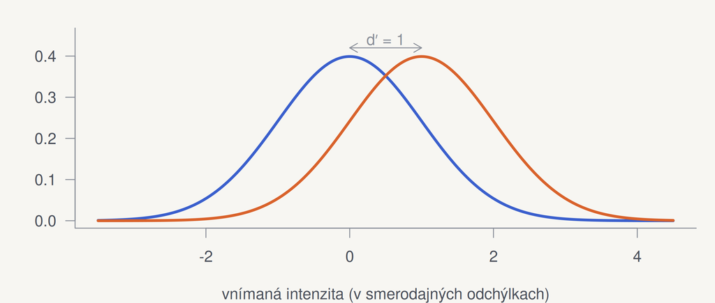

```r
z <- seq(-3.5, 4.5, length.out = 300)
plot(z, dnorm(z), type = "l", lwd = 3, col = pal[3], ylim = c(0, 0.45),
     xlab = "vnímaná intenzita (v smerodajných odchýlkach)", ylab = "")
lines(z, dnorm(z, mean = 1), lwd = 3, col = pal[2])
arrows(0, 0.42, 1, 0.42, code = 3, length = 0.1); text(0.5, 0.44, "d′ = 1")
```

Vnem pri každom ochutnaní kolíše. **d′** = vzdialenosť dvoch rozdelení v smerodajných odchýlkach – miera rozdielu nezávislá od metódy.

## Psychometrické funkcie

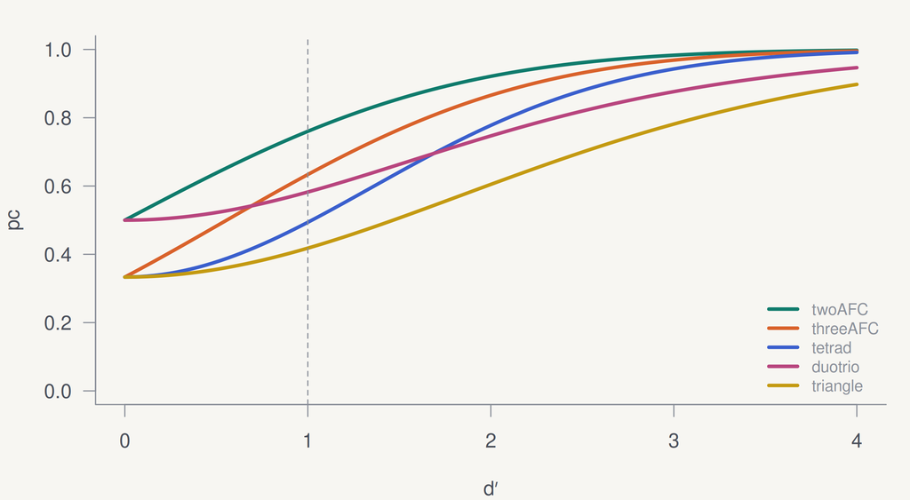

```r
metody <- c("twoAFC", "threeAFC", "tetrad",
            "duotrio", "triangle")
curve(psyfun(x, method = "twoAFC"), 0, 4,
      lwd = 3, col = pal[1], ylim = c(0, 1),
      xlab = "d′", ylab = "pc")
for (i in 2:5) curve(psyfun(x, method = metody[i]),
                     add = TRUE, lwd = 3, col = pal[i])
abline(v = 1, lty = 2)
legend("bottomright", metody, col = pal, lwd = 3,
       bty = "n", cex = 0.8)
```

```r
round(sapply(metody, function(m) psyfun(1, method = m)), 2)
```

```
  twoAFC threeAFC   tetrad  duotrio triangle
    0.76     0.63     0.49     0.58     0.42
```

## `discrim()` – od pc k d′

```r
discrim(42, 100, method = "triangle")
```

```
Estimates for the triangle discrimination protocol with 42 correct
answers in 100 trials. One-sided p-value and 95 % two-sided confidence
intervals are based on the 'exact' binomial test.

        Estimate Std. Error  Lower  Upper
pc         0.420    0.04936 0.3333 0.5229
pd         0.130    0.07403 0.0000 0.2843
d-prime    1.012    0.31377 0.0000 1.5849

Result of difference test:
'exact' binomial test:  p-value = 0.04337
Alternative hypothesis: d-prime is greater than 0
```

## Porovnanie dvoch testov

```r
rbind(
  triangel = coef(discrim(42, 100, method = "triangle"))["d-prime", ],
  duotrio  = coef(discrim(36, 50, method = "duotrio"))["d-prime", ]
) |> round(2)
```

```
         Estimate Std. Error Lower Upper
triangel     1.01       0.31  0.00  1.58
duotrio      1.83       0.38  0.95  2.64
```

Duo-trio 36/50 (72 %) zodpovedá d′ = 1,83 – takmer dvojnásobný rozdiel oproti trianglu (d′ = 1,01). Bez d′ by sme to nevideli.

## Test podobnosti

Pri zmene dodávateľa chceme preukázať, že vzorky sú **dostatočne rovnaké**.

```r
discrim(38, 100, method = "triangle", test = "similarity", pd0 = 0.2)$p.value
```

```
[1] 0.05017911
```

Nevýznamný test rozdielu **nie je** dôkaz podobnosti. Podobnosť sa testuje s vopred zvolenou hranicou pd₀ (napr. najviac 20 % rozlišovateľov).

## KVÍZ Rozdiel alebo podobnosť?

Znížili ste cukor o 10 % a chcete na obale nechať „rovnaká chuť“. Ktorý test?

**Test podobnosti** (`test = "similarity"`). Test rozdielu by pri nevýznamnom výsledku tvrdenie nepodložil – mohol len chýbať dostatok hodnotiteľov.

## Sila testu

|  | rozdiel nie je | rozdiel je |
| --- | --- | --- |
| test preukazný | chyba I. druhu α | **sila 1 − β** |
| test nepreukazný | správne | chyba II. druhu β |

Sila = pravdepodobnosť, že test odhalí rozdiel, ktorý naozaj existuje. Plánujeme aspoň **80 %**.

## Sila trianglu podľa veľkosti panelu

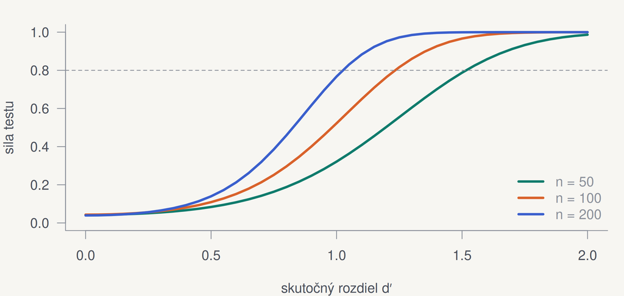

```r
d <- seq(0, 2, by = 0.05)
plot(NA, xlim = c(0, 2), ylim = c(0, 1), xlab = "skutočný rozdiel d′", ylab = "sila testu")
for (i in 1:3) {
  n <- c(50, 100, 200)[i]
  lines(d, sapply(d, d.primePwr, sample.size = n, method = "triangle"), lwd = 3, col = pal[i])
}
abline(h = 0.8, lty = 2); legend("bottomright", c("n = 50", "n = 100", "n = 200"), col = pal[1:3], lwd = 3, bty = "n")
```

## Koľko hodnotiteľov pre d′ = 1?

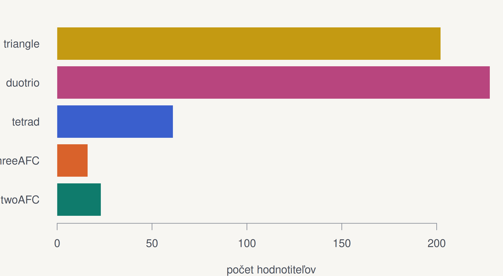

```r
n <- sapply(metody, function(m)
  d.primeSS(1, target.power = 0.8, method = m))
barplot(n, col = pal, border = NA, horiz = TRUE,
        las = 1, xlab = "počet hodnotiteľov")
```

```r
n
```

```
  twoAFC threeAFC   tetrad  duotrio triangle
      23       16       61      228      202
```

## Odpoveď pre cvičenie 5a

Párová preferencia: 34 zo 60 (57 %), p = 0,37. Ak je preferencia naozaj 57 %:

```r
pd <- 2 * 34 / 60 - 1
c(sila_pri_60 = discrimPwr(pd, sample.size = 60, pGuess = 1 / 2),
  potrebne_n = discrimSS(pd, target.power = 0.8, pGuess = 1 / 2))
```

```
sila_pri_60  potrebne_n
    0.25869   350.00000
```

So 60 ľuďmi mal test silu len 26 % – nevýznamný výsledok bol takmer istý. Na 80 % treba asi 350 spotrebiteľov.

## Škálové dáta

```r
c(parovy = power.t.test(delta = 0.5, sd = 1, power = 0.8, type = "paired")$n,
  dve_skupiny = power.t.test(delta = 0.5, sd = 1, power = 0.8)$n) |> ceiling()
```

```
     parovy dve_skupiny
         34          64
```

Rovnaký rozdiel 0,5 bodu: párový dizajn potrebuje 34 hodnotiteľov, dve nezávislé skupiny 2 × 64. **Nechajte každého hodnotiť všetky vzorky**, ak sa dá.

## Zhrnutie

- **d′** je miera rozdielu nezávislá od metódy; pc a pd závisia od testu.
- Podobnosť sa preukazuje **testom podobnosti**, nie nevýznamným testom rozdielu.
- Veľkosť panelu plánujte **pred** experimentom: rozdiel, α, sila 80 %.
- Citlivé metódy (2-AFC, tetráda) šetria hodnotiteľov.

Teória 13 Teória 14